# Cu2+ Toxicity in plants

# Experiment Description

The experiment aims to measure the effect of Cu2+ on the growth of plants. For this purpose, a sample of garden cress seeds were planted in petri dishes infused with different concentrations of **CuSO4.5H2O**. The concentrations were **3.125mg/l, 6.25mg/l, 12.5mg/l, 25mg/l, 50mg/l and 100mg/l**, **three** petri dishes for each concentration with **22-25** seeds planted in each petri dish. A control sample of 3 petri dishes with 22-25 seeds infused with distilled water was also planted.

After a week, each petri dish was taken out and all the seeds were measured by root length in mm, stem length in mm and the sum of both was calculated also in mm. It was also noted which ones had branched roots as this is also supposed to be an indicator for the presence of a toxicant.

Experiment was held as a practical class part of the Ecological monitoring discipline at Faculty of Biology, Sofia University.

## Task #1 and #2

Calculate mean and standard deviation of the control sample and each concentration. Calculate the percentage of inhibition - if the control sample has a mean of X and the current sample has a mean of Y, then the growth percent compared to the control would be (Y/X)*100 and the inhibition percent would be 100 - (Y/X)*100.

```r
# Reading control sample data
k = read.csv('../data/K.csv')
k
```

| X | root_size | stem_size | root_branching | sum |
| --- | --- | --- | --- | --- |
| 1 | 70 | 32 | 0 | 102 |
| 2 | 68 | 28 | 0 | 96 |
| 3 | 94 | 22 | 0 | 116 |
| 4 | 70 | 24 | 0 | 94 |
| 5 | 79 | 36 | 0 | 115 |
| 6 | 53 | 28 | 1 | 81 |
| 7 | 58 | 28 | 0 | 86 |
| 8 | 31 | 14 | 0 | 45 |
| 9 | 75 | 30 | 0 | 105 |
| 10 | 35 | 26 | 0 | 61 |

[output cut: 55 more lines]

```r
# Control sample root_size mean and standard deviation
control_root = mean(k$root_size)
control_root
```

```
## [1] 63.41538
```

```r
sd(k$root_size)
```

```
## [1] 25.321
```

```r
# Control sample stem_size mean and standard deviation
control_stem = mean(k$stem_size)
control_stem
```

```
## [1] 25.63077
```

```r
sd(k$stem_size)
```

```
## [1] 5.893771
```

```r
# Control sample sum mean and standard deviation
control_sum = mean(k$sum)
control_sum
```

```
## [1] 89.04615
```

```r
sd(k$sum)
```

```
## [1] 28.27843
```

```r
# Reading data for 100mg/l concentration of Cu2+
conc_100mg = read.csv('../data/100mg.csv')
conc_100mg
```

| X | root_size | stem_size | root_branching | sum |
| --- | --- | --- | --- | --- |
| 1 | 11 | 22 | 0 | 33 |
| 2 | 0 | 18 | 0 | 18 |
| 3 | 6 | 25 | 0 | 31 |
| 4 | 4 | 22 | 0 | 26 |
| 5 | 4 | 24 | 0 | 28 |
| 6 | 8 | 18 | 0 | 26 |
| 7 | 14 | 18 | 0 | 32 |
| 8 | 5 | 10 | 0 | 15 |
| 9 | 3 | 7 | 0 | 10 |
| 10 | 4 | 15 | 0 | 19 |

[output cut: 56 more lines]

```r
# 100mg/l root_size mean and standard deviation
root_100mg = mean(conc_100mg$root_size)
root_100mg
```

```
## [1] 8.318182
```

```r
sd(conc_100mg$root_size)
```

```
## [1] 6.450186
```

```r
# Root growth inhibition percentage, compared to control sample
root_limit_100mg = 100 - (root_100mg/control_root)*100
root_limit_100mg
```

```
## [1] 86.88302
```

```r
# 100mg/l stem_size mean and standard deviation
stem_100mg = mean(conc_100mg$stem_size)
stem_100mg
```

```
## [1] 20.51515
```

```r
sd(conc_100mg$stem_size)
```

```
## [1] 7.423958
```

```r
# Stem growth inhibition percentage, compared to control sample
stem_limit_100mg = 100 - (stem_100mg/control_stem)*100
stem_limit_100mg
```

```
## [1] 19.95889
```

```r
# 100mg/l sum mean and standard deviation
sum_100mg = mean(conc_100mg$sum)
sum_100mg
```

```
## [1] 28.83333
```

```r
sd(conc_100mg$sum)
```

```
## [1] 10.74256
```

```r
# Overall growth inhibition percentage, compared to control sample
sum_limit_100mg = 100 - (sum_100mg/control_sum)*100
sum_limit_100mg
```

```
## [1] 67.61979
```

```r
# Reading data for 50mg/l concentration of Cu2+
conc_50mg = read.csv('../data/50mg.csv')
conc_50mg
```

| X | root_size | stem_size | root_branching | sum |
| --- | --- | --- | --- | --- |
| 1 | 32 | 29 | 0 | 61 |
| 2 | 20 | 39 | 1 | 59 |
| 3 | 20 | 26 | 0 | 46 |
| 4 | 10 | 32 | 1 | 42 |
| 5 | 6 | 20 | 1 | 26 |
| 6 | 8 | 18 | 0 | 26 |
| 7 | 22 | 30 | 1 | 52 |
| 8 | 30 | 22 | 1 | 52 |
| 9 | 27 | 29 | 1 | 56 |
| 10 | 33 | 24 | 1 | 57 |

[output cut: 56 more lines]

```r
# 50mg/l root_size mean and standard deviation
root_50mg = mean(conc_50mg$root_size)
root_50mg
```

```
## [1] 20.4697
```

```r
sd(conc_50mg$root_size)
```

```
## [1] 11.95147
```

```r
# Root growth inhibition percentage, compared to control sample
root_limit_50mg = 100 - (root_50mg/control_root)*100
root_limit_50mg
```

```
## [1] 67.72124
```

```r
# 50mg/l stem_size mean and standard deviation
stem_50mg = mean(conc_50mg$stem_size)
stem_50mg
```

```
## [1] 26.59091
```

```r
sd(conc_50mg$stem_size)
```

```
## [1] 8.494301
```

```r
# Stem growth inhibition percentage, compared to control sample
stem_limit_50mg = 100 - (stem_50mg/control_stem)*100
stem_limit_50mg
```

```
## [1] -3.746044
```

```r
# 50mg/l sum mean and standard deviation
sum_50mg = mean(conc_50mg$sum)
sum_50mg
```

```
## [1] 47.06061
```

```r
sd(conc_50mg$sum)
```

```
## [1] 14.81878
```

```r
# Overall growth inhibition percentage, compared to control sample
sum_limit_50mg = 100 - (sum_50mg/control_sum)*100
sum_limit_50mg
```

```
## [1] 47.15032
```

```r
# Reading data for 25mg/l concentration of Cu2+
conc_25mg = read.csv('../data/25mg.csv')
conc_25mg
```

| X | root_size | stem_size | root_branching | sum |
| --- | --- | --- | --- | --- |
| 1 | 28 | 34 | 0 | 62 |
| 2 | 20 | 25 | 1 | 45 |
| 3 | 22 | 26 | 1 | 48 |
| 4 | 21 | 26 | 0 | 47 |
| 5 | 18 | 32 | 1 | 50 |
| 6 | 17 | 42 | 0 | 59 |
| 7 | 61 | 29 | 0 | 90 |
| 8 | 49 | 29 | 0 | 78 |
| 9 | 36 | 30 | 0 | 66 |
| 10 | 66 | 30 | 0 | 96 |

[output cut: 54 more lines]

```r
# 25mg/l root_size mean + standard deviation
root_25mg = mean(conc_25mg$root_size)
root_25mg
```

```
## [1] 34.85938
```

```r
sd(conc_25mg$root_size)
```

```
## [1] 19.73464
```

```r
# Root growth inhibition percentage, compared to control sample
root_limit_25mg = 100 - (root_25mg/control_root)*100
root_limit_25mg
```

```
## [1] 45.0301
```

```r
# 25mg/l stem_size mean + standard deviation
stem_25mg = mean(conc_25mg$stem_size)
stem_25mg
```

```
## [1] 27.67188
```

```r
sd(conc_25mg$stem_size)
```

```
## [1] 6.118031
```

```r
# Stem growth inhibition percentage, compared to control sample
stem_limit_25mg = 100 - (stem_25mg/control_stem)*100
stem_limit_25mg
```

```
## [1] -7.963498
```

```r
# 25mg/l sum mean + standard deviation
sum_25mg = mean(conc_25mg$sum)
sum_25mg
```

```
## [1] 62.53125
```

```r
sd(conc_25mg$sum)
```

```
## [1] 22.12516
```

```r
# Overall growth inhibition percentage, compared to control sample
sum_limit_25mg = 100 - (stem_25mg/control_sum)*100
sum_limit_25mg
```

```
## [1] 68.92412
```

```r
# Reading data for 12.5mg/l concentration of Cu2+
conc_12.5mg = read.csv('../data/12.5mg.csv')
conc_12.5mg
```

| X | root_size | stem_size | root_branching | sum |
| --- | --- | --- | --- | --- |
| 1 | 47 | 21 | 0 | 68 |
| 2 | 80 | 44 | 0 | 124 |
| 3 | 60 | 35 | 0 | 95 |
| 4 | 50 | 15 | 0 | 65 |
| 5 | 95 | 33 | 0 | 128 |
| 6 | 60 | 30 | 0 | 90 |
| 7 | 74 | 38 | 0 | 112 |
| 8 | 70 | 34 | 0 | 104 |
| 9 | 65 | 39 | 0 | 104 |
| 10 | 110 | 35 | 0 | 145 |

[output cut: 56 more lines]

```r
# 12.5mg/l root_size mean + standard deviation
root_12.5mg = mean(conc_12.5mg$root_size)
root_12.5mg
```

```
## [1] 63.90909
```

```r
sd(conc_12.5mg$root_size)
```

```
## [1] 22.73576
```

```r
# Root growth inhibition percentage, compared to control sample
root_limit_12.5mg = 100 - (root_12.5mg/control_root)*100
root_limit_12.5mg
```

```
## [1] -0.7785276
```

```r
# 12.5mg/l stem_size mean + standard deviation
stem_12.5mg = mean(conc_12.5mg$stem_size)
stem_12.5mg
```

```
## [1] 27.5303
```

```r
sd(conc_12.5mg$stem_size)
```

```
## [1] 7.22436
```

```r
# Stem growth inhibition percentage, compared to control sample
stem_limit_12.5mg = 100 - (stem_12.5mg/control_stem)*100
stem_limit_12.5mg
```

```
## [1] -7.411146
```

```r
# 12.5mg/l sum mean + standard deviation
sum_12.5mg = mean(conc_12.5mg$sum)
sum_12.5mg
```

```
## [1] 91.43939
```

```r
sd(conc_12.5mg$sum)
```

```
## [1] 25.94855
```

```r
# Overall growth inhibition percentage, compared to control sample
sum_limit_12.5mg = 100 - (sum_12.5mg/control_sum)*100
sum_limit_12.5mg
```

```
## [1] -2.68764
```

```r
# Reading data for 6.25mg/l concentration of Cu2+
conc_6.25mg = read.csv('../data/6.25mg.csv')
conc_6.25mg
```

| X | root_size | stem_size | root_branching | sum |
| --- | --- | --- | --- | --- |
| 1 | 64 | 23 | 0 | 87 |
| 2 | 66 | 35 | 0 | 101 |
| 3 | 25 | 28 | 0 | 53 |
| 4 | 65 | 31 | 0 | 96 |
| 5 | 75 | 19 | 0 | 94 |
| 6 | 66 | 26 | 0 | 92 |
| 7 | 60 | 27 | 0 | 87 |
| 8 | 62 | 25 | 0 | 87 |
| 9 | 20 | 26 | 0 | 46 |
| 10 | 95 | 25 | 0 | 120 |

[output cut: 58 more lines]

```r
# 6.25mg/l root_size mean + standard deviation
root_6.25mg = mean(conc_6.25mg$root_size)
root_6.25mg
```

```
## [1] 57.44118
```

```r
sd(conc_6.25mg$root_size)
```

```
## [1] 20.38904
```

```r
# Root growth inhibition percentage, compared to control sample
root_limit_6.25mg = 100 - (root_6.25mg/control_root)*100
root_limit_6.25mg
```

```
## [1] 9.420755
```

```r
# 6.25mg/l stem_size mean + standard deviation
stem_6.25mg = mean(conc_6.25mg$stem_size)
stem_6.25mg
```

```
## [1] 27.05882
```

```r
sd(conc_6.25mg$stem_size)
```

```
## [1] 6.70683
```

```r
# Stem growth inhibition percentage, compared to control sample
stem_limit_6.25mg = 100 - (stem_6.25mg/control_stem)*100
stem_limit_6.25mg
```

```
## [1] -5.57164
```

```r
# 6.25mg/l sum mean + standard deviation
sum_6.25mg = mean(conc_6.25mg$sum)
sum_6.25mg
```

```
## [1] 84.5
```

```r
sd(conc_6.25mg$sum)
```

```
## [1] 23.63939
```

```r
# Overall growth inhibition percentage, compared to control sample
sum_limit_6.25mg = 100 - (sum_6.25mg/control_sum)*100
sum_limit_6.25mg
```

```
## [1] 5.10539
```

```r
# Reading data for 3.125mg/l concentration of Cu2+
conc_3.125mg = read.csv('../data/3.125mg.csv')
conc_3.125mg
```

| X | root_size | stem_size | root_branching | sum |
| --- | --- | --- | --- | --- |
| 1 | 73 | 29 | 0 | 102 |
| 2 | 63 | 33 | 0 | 96 |
| 3 | 64 | 22 | 0 | 86 |
| 4 | 41 | 21 | 0 | 62 |
| 5 | 63 | 23 | 0 | 86 |
| 6 | 48 | 25 | 0 | 73 |
| 7 | 58 | 16 | 0 | 74 |
| 8 | 8 | 26 | 0 | 34 |
| 9 | 53 | 29 | 0 | 82 |
| 10 | 47 | 16 | 0 | 63 |

[output cut: 59 more lines]

```r
# 3.125mg/l root_size mean + standard deviation
root_3.125mg = mean(conc_3.125mg$root_size)
root_3.125mg
```

```
## [1] 52.10145
```

```r
sd(conc_3.125mg$root_size)
```

```
## [1] 23.53979
```

```r
# Root growth inhibition percentage, compared to control sample
root_limit_3.125mg = 100 - (root_3.125mg/control_root)*100
root_limit_3.125mg
```

```
## [1] 17.84099
```

```r
# 3.125mg/l stem_size mean and standard deviation
stem_3.125mg = mean(conc_3.125mg$stem_size)
stem_3.125mg
```

```
## [1] 23.71014
```

```r
sd(conc_3.125mg$stem_size)
```

```
## [1] 9.698547
```

```r
# Stem growth inhibition percentage, compared to control sample
stem_limit_3.125mg = 100 - (stem_3.125mg/control_stem)*100
stem_limit_3.125mg
```

```
## [1] 7.493432
```

```r
# 3.125mg/l sum mean and standard deviation
sum_3.125mg = mean(conc_3.125mg$sum)
sum_3.125mg
```

```
## [1] 75.81159
```

```r
sd(conc_3.125mg$sum)
```

```
## [1] 26.31555
```

```r
# Overall growth inhibition percentage, compared to control sample
sum_limit_3.125mg = 100 - (sum_3.125mg/control_sum)*100
sum_limit_3.125mg
```

```
## [1] 14.86258
```

## Task #3, #4 and #5

Plot the inhibition percentage as a function of the concentration. Create a linear model approximation and get the coefficients. Use the coefficients to calculate the concentration needed to cause a 50% growth inhibition.

```r
x = c(3.125, 6.25, 12.5, 25, 50, 100)
y_root = c(root_limit_3.125mg, root_limit_6.25mg, root_limit_12.5mg, root_limit_25mg, root_limit_50mg, root_limit_100mg)
y_stem = c(stem_limit_3.125mg, stem_limit_6.25mg, stem_limit_12.5mg, stem_limit_25mg, stem_limit_50mg, stem_limit_100mg)
y_sum = c(sum_limit_3.125mg, sum_limit_6.25mg, sum_limit_12.5mg, sum_limit_25mg, sum_limit_50mg, sum_limit_100mg)
```

```r
library(ggplot2)
```

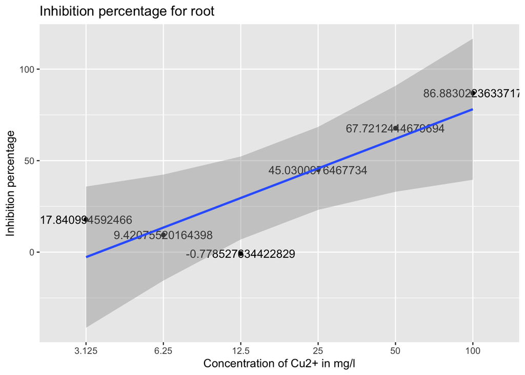

```r
df_root = data.frame(x,y_root)
ggplot(df_root, aes(x=factor(x), y=y_root, group=1)) + geom_point() + geom_text(aes(label=y_root)) + stat_smooth(method='lm') + ggtitle('Inhibition percentage for root') + ylab('Inhibition percentage') + xlab('Concentration of Cu2+ in mg/l')
```

```r
model_root = lm(y_root ~ x, data = df_root)
model_root
```

```
##
## Call:
## lm(formula = y_root ~ x, data = df_root)
##
## Coefficients:
## (Intercept)            x
##      9.5762       0.8567
```

```r
b0_root = summary(model_root)$coefficients[1,1]
b1_root = summary(model_root)$coefficients[2,1]
ec50_root = (50 - b0_root)/b1_root
ec50_root
```

```
## [1] 47.18618
```

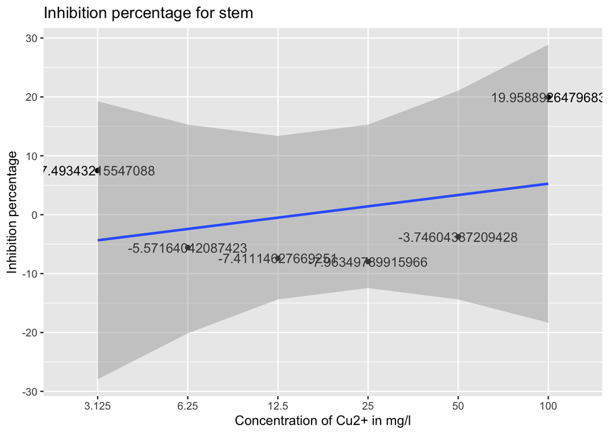

```r
df_stem = data.frame(x,y_stem)
ggplot(df_stem, aes(x=factor(x), y=y_stem, group=1)) + geom_point() + geom_text(aes(label=y_stem)) + stat_smooth(method='lm') + ggtitle('Inhibition percentage for stem') + ylab('Inhibition percentage') + xlab('Concentration of Cu2+ in mg/l')
```

```r
model_stem = lm(y_stem ~ x, data = df_stem)
model_stem
```

```
##
## Call:
## lm(formula = y_stem ~ x, data = df_stem)
##
## Coefficients:
## (Intercept)            x
##     -6.2977       0.2059
```

```r
b0_stem = summary(model_stem)$coefficients[1,1]
b1_stem = summary(model_stem)$coefficients[2,1]
ec50_stem = (50 - b0_stem)/b1_stem
ec50_stem
```

```
## [1] 273.3578
```

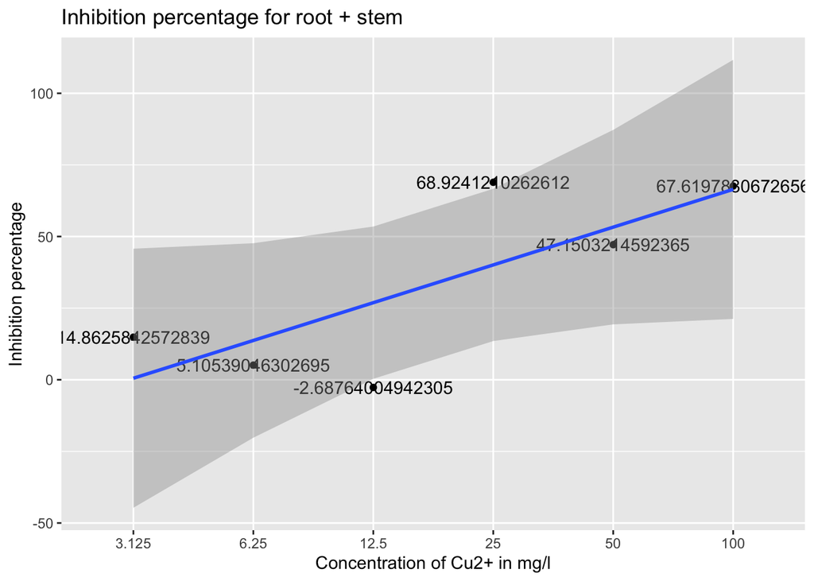

```r
df_sum = data.frame(x,y_sum)
ggplot(df_sum, aes(x=factor(x), y=y_sum, group=1)) + geom_point() + geom_text(aes(label=y_sum)) + stat_smooth(method='lm') + ggtitle('Inhibition percentage for root + stem') + ylab('Inhibition percentage') + xlab('Concentration of Cu2+ in mg/l')
```

```r
model_sum = lm(y_sum ~ x, data = df_sum)
model_sum
```

```
##
## Call:
## lm(formula = y_sum ~ x, data = df_sum)
##
## Coefficients:
## (Intercept)            x
##     12.9925       0.6249
```

```r
b0_sum = summary(model_sum)$coefficients[1,1]
b1_sum = summary(model_sum)$coefficients[2,1]
ec50_sum = (50 - b0_sum)/b1_sum
ec50_sum
```

```
## [1] 59.22509
```

## Task #6 and #7

Compare the concentration values causing a 50% inhibition in the root, stem and overall. Conclude which part of the plant is most susceptible to the toxicant.

```r
ec50 = c(ec50_root,ec50_stem,ec50_sum)
names = c("root", "stem", "sum")
df_ec50 = data.frame(names, ec50)
df_ec50
```

| names | ec50 |
| --- | --- |
| root | 47.18618 |
| stem | 273.35777 |
| sum | 59.22509 |

In this case we need the lowest concentration able to create a 50% growth inhibition. The table shows this is the value associated with the root - i.e. the root is most susceptible to the toxicant.

## Bonus

Plot the number of branched roots for each concentration.

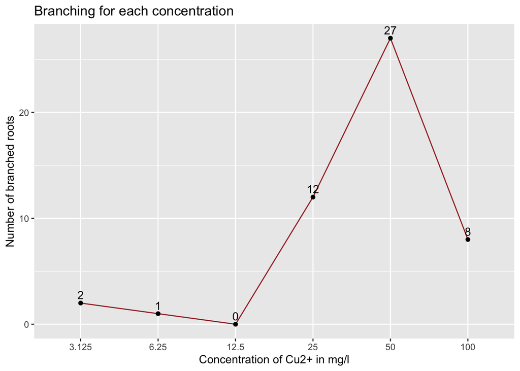

```r
branched = c(sum(conc_3.125mg$root_branching), sum(conc_6.25mg$root_branching), sum(conc_12.5mg$root_branching), sum(conc_25mg$root_branching), sum(conc_50mg$root_branching), sum(conc_100mg$root_branching))
df_branched = data.frame(x, branched)
ggplot(df_branched, aes(x=factor(x), y=branched, group=1)) + geom_line(color="brown") + geom_point() + geom_text(aes(label=branched), vjust = -0.5) + ggtitle('Branching for each concentration') + ylab('Number of branched roots') + xlab('Concentration of Cu2+ in mg/l')
```